# Prediction of patient with liver desease

## Introduction

The **liver** is an organ about the size of a football. It sits just the rib cage on the right side of the abdomen. It is one on the most important organs of our body and it is responsible for digesting food and ridding our body of toxic substances. Such role of filtering makes it vulnerable to the toxins it processes. Too many toxins can overwhelm liver's resources and ability to function. This can happen temporarily or over a long period of time.

Usually, **liver diseases are chronic conditions** that do progressive damage to the organ over time. Among common causes we find genetic inheritance, viruses, alcohol abuse and obesity. The liver has a great regenerative power but conditions that damage it can lead to scarring (cirrhosis), which can lead to liver failure.

Every year in Italy, approximately 15 thousands patients die of cirrhosis and about 6 thounsands die of liver cancer. It is **important to identify** possible liver infections at an early stage in order to adopt treatments that may give the liver time to heal.

## Research question

Given the criticity of a condition like liver disease, it is important to being able to identify potential infections and dangers at an early stage. This is the only way to aid the organ in the purging of the infection and the starting of the healing process.

Machine Learning can be of great help, allowing to solve the problem via automation of the analysis of the patient. In this project I will try to create and validate a **model that predicts whether a patient suffers of liver disease or not**.

As mentioned in the documentation of the dataset that I choose, previous researches on this field have pointed out how there is a **difference in the effect of predicting diseases in case of male and female patients**. Another point of this project is to try to verify this behavior with the mentioned dataset.

## Dataset

The dataset that I'm going to use for this project is ILPD (Indian Liver Patient Dataset) and it can be found [here](https://archive.ics.uci.edu/dataset/225/ilpd+indian+liver+patient+dataset). It comprises 583 patient records collected from the NorthEast of Andhra Pradesh, India. Variables contains information about several biochemical markers and a target variable that indicates if the patient suffers from live desease.

One limitation of the dateset may be that the target variable is a bit imbalanced: 416 patients with disease and 167 patients without disease. This can be managed during validation phase. On the other hand, the dataset seems to have no missing data. We will verify this later.

Let's quickly explore the variables of the dataset:

- **Age**: Age of the patient [years]
- **Gender**: Gender of the patient [Male/Female]
- **TB**: Total Bilirubin [mg/dL]
- **DB**: Direct Bilirubin [mg/dL]
- **Alkphos**: Alkaline Phosphotase [unit/L]
- **Sgpt**: Alamine Aminotransferase [unit/L]
- **Sgot**: Aspartate Aminotransferase [unit/L]
- **TP**: Total Proteins [g/dL]
- **ALB**: Albumin [g/100mL]
- **A/G Ratio**: Albumin and Globulin Ratio
- **Selector**: indicates if patient suffers of liver disease [1:Yes, 2:No]

All variables (except for Age, Gender, Selector) refers to components that are related either to blood or liver. They are usually tested to check, among many disease, for liver anomalies.

## Preprocessing data

```python
import pandas as pd
import numpy as np
import scipy.stats as ss
from sklearn.preprocessing import RobustScaler,StandardScaler
from sklearn.feature_selection import SelectKBest, f_classif
from sklearn.decomposition import PCA
from imblearn.pipeline import Pipeline
from imblearn.over_sampling import RandomOverSampler
from sklearn.linear_model import LogisticRegression
from sklearn.tree import DecisionTreeClassifier
from sklearn.neighbors import KNeighborsClassifier
from sklearn.svm import SVC
from sklearn.dummy import DummyClassifier
from sklearn.metrics import classification_report, confusion_matrix, roc_auc_score
from sklearn.metrics import precision_recall_curve, roc_curve, auc
from sklearn.model_selection import StratifiedKFold, RepeatedStratifiedKFold, train_test_split, GridSearchCV
import pylab
import ast

import warnings
warnings.filterwarnings('ignore')

import matplotlib.pyplot as plt
import seaborn as sns
import matplotlib
matplotlib.style.use('Solarize_Light2')
```

```python
ds = pd.read_csv('data/Indian_Liver_Patient_Dataset_(ILPD).csv',
                 names = ['Age',
                          'Gender',
                          'TB',
                          'DB',
                          'Alkphos',
                          'Sgpt',
                          'Sgot',
                          'TP',
                          'ALB',
                          'A/G Ratio',
                          'Selector'])
ds.head()
```

|  | Age | Gender | TB | DB | Alkphos | Sgpt | Sgot | TP | ALB | A/G Ratio | Selector |
| --- | --- | --- | --- | --- | --- | --- | --- | --- | --- | --- | --- |
| 0 | 65 | Female | 0.7 | 0.1 | 187 | 16 | 18 | 6.8 | 3.3 | 0.90 | 1 |
| 1 | 62 | Male | 10.9 | 5.5 | 699 | 64 | 100 | 7.5 | 3.2 | 0.74 | 1 |
| 2 | 62 | Male | 7.3 | 4.1 | 490 | 60 | 68 | 7.0 | 3.3 | 0.89 | 1 |
| 3 | 58 | Male | 1.0 | 0.4 | 182 | 14 | 20 | 6.8 | 3.4 | 1.00 | 1 |
| 4 | 72 | Male | 3.9 | 2.0 | 195 | 27 | 59 | 7.3 | 2.4 | 0.40 | 1 |

```python
ds.columns
```

```
Index(['Age', 'Gender', 'TB', 'DB', 'Alkphos', 'Sgpt', 'Sgot', 'TP', 'ALB',
       'A/G Ratio', 'Selector'],
      dtype='object')
```

```python
ds.info()
```

```
<class 'pandas.core.frame.DataFrame'>
RangeIndex: 583 entries, 0 to 582
Data columns (total 11 columns):
 #   Column     Non-Null Count  Dtype
---  ------     --------------  -----
 0   Age        583 non-null    int64
 1   Gender     583 non-null    object
 2   TB         583 non-null    float64
 3   DB         583 non-null    float64
 4   Alkphos    583 non-null    int64
 5   Sgpt       583 non-null    int64
 6   Sgot       583 non-null    int64
 7   TP         583 non-null    float64
 8   ALB        583 non-null    float64
 9   A/G Ratio  579 non-null    float64
 10  Selector   583 non-null    int64
dtypes: float64(5), int64(5), object(1)
memory usage: 50.2+ KB
```

Let's change the type of column **Gender** from 'object' to 'string'

```python
str_col = ds.select_dtypes(include="object").columns
ds[str_col]=ds[str_col].astype("string")
```

```python
ds.info()
```

```
<class 'pandas.core.frame.DataFrame'>
RangeIndex: 583 entries, 0 to 582
Data columns (total 11 columns):
 #   Column     Non-Null Count  Dtype
---  ------     --------------  -----
 0   Age        583 non-null    int64
 1   Gender     583 non-null    string
 2   TB         583 non-null    float64
 3   DB         583 non-null    float64
 4   Alkphos    583 non-null    int64
 5   Sgpt       583 non-null    int64
 6   Sgot       583 non-null    int64
 7   TP         583 non-null    float64
 8   ALB        583 non-null    float64
 9   A/G Ratio  579 non-null    float64
 10  Selector   583 non-null    int64
dtypes: float64(5), int64(5), string(1)
memory usage: 50.2 KB
```

### Missing values

Let's verify absence of missing values

```python
ds.isnull().sum()
```

```
Age          0
Gender       0
TB           0
DB           0
Alkphos      0
Sgpt         0
Sgot         0
TP           0
ALB          0
A/G Ratio    4
Selector     0
dtype: int64
```

Actually, there are 4 missing data in **A/G Ratio** column. Luckily, we can resolve this issue: by domain knowledge, we know that **TP** (Total Protein) is approximately the sum of **ALB** (Albumin) and Globulin. We can retrieve Globulin amount from the two columns **TP** and **ALB** (**GLB** = **TP** - **ALB**) and compute the missing values of **A/G Ratio** (Albumin and Globulin Ratio). To be fair, this is not 100% correct because Total Protein takes into account all types of protein inside blood. However, Albumin and Globulin are found in the highest concentration so, for the sake of retreiving 4 missing values, we can rely on this simplyfication of the formula.

```python
ds['A/G Ratio'] = ds['A/G Ratio'].fillna(ds['ALB']/(ds["TP"] - ds["ALB"]))

ds.insert(9, "GLB", round((1/ds["A/G Ratio"]) * ds["ALB"], 1))
ds.head()
```

|  | Age | Gender | TB | DB | Alkphos | Sgpt | Sgot | TP | ALB | GLB | A/G Ratio | Selector |
| --- | --- | --- | --- | --- | --- | --- | --- | --- | --- | --- | --- | --- |
| 0 | 65 | Female | 0.7 | 0.1 | 187 | 16 | 18 | 6.8 | 3.3 | 3.7 | 0.90 | 1 |
| 1 | 62 | Male | 10.9 | 5.5 | 699 | 64 | 100 | 7.5 | 3.2 | 4.3 | 0.74 | 1 |
| 2 | 62 | Male | 7.3 | 4.1 | 490 | 60 | 68 | 7.0 | 3.3 | 3.7 | 0.89 | 1 |
| 3 | 58 | Male | 1.0 | 0.4 | 182 | 14 | 20 | 6.8 | 3.4 | 3.4 | 1.00 | 1 |
| 4 | 72 | Male | 3.9 | 2.0 | 195 | 27 | 59 | 7.3 | 2.4 | 6.0 | 0.40 | 1 |

Now we don't have any missing value.

```python
ds.isnull().sum()
```

```
Age          0
Gender       0
TB           0
DB           0
Alkphos      0
Sgpt         0
Sgot         0
TP           0
ALB          0
GLB          0
A/G Ratio    0
Selector     0
dtype: int64
```

Following the previous intuition, we can rely one more time on domain knowledge and create a new column called **IB** (Indirect Bilirubin [mg/dL]). The Total Bilirubin is the sum of Direct Bilirubin and Indirect Bilirubin. Later on, during Feature Analysis we will check if this is worth it or not.

```python
ds.insert(3, "IB", round(ds['TB'] - ds['DB'], 1))
```

```python
ds.describe().T
```

|  | count | mean | std | min | 25% | 50% | 75% | max |
| --- | --- | --- | --- | --- | --- | --- | --- | --- |
| Age | 583.0 | 44.746141 | 16.189833 | 4.0 | 33.0 | 45.00 | 58.0 | 90.0 |
| TB | 583.0 | 3.298799 | 6.209522 | 0.4 | 0.8 | 1.00 | 2.6 | 75.0 |
| IB | 583.0 | 1.812693 | 3.992511 | -7.2 | 0.6 | 0.70 | 1.4 | 71.4 |
| DB | 583.0 | 1.486106 | 2.808498 | 0.1 | 0.2 | 0.30 | 1.3 | 19.7 |
| Alkphos | 583.0 | 290.576329 | 242.937989 | 63.0 | 175.5 | 208.00 | 298.0 | 2110.0 |
| Sgpt | 583.0 | 80.713551 | 182.620356 | 10.0 | 23.0 | 35.00 | 60.5 | 2000.0 |
| Sgot | 583.0 | 109.910806 | 288.918529 | 10.0 | 25.0 | 42.00 | 87.0 | 4929.0 |
| TP | 583.0 | 6.483190 | 1.085451 | 2.7 | 5.8 | 6.60 | 7.2 | 9.6 |
| ALB | 583.0 | 3.141852 | 0.795519 | 0.9 | 2.6 | 3.10 | 3.8 | 5.5 |
| GLB | 583.0 | 3.466209 | 0.751590 | 1.0 | 3.0 | 3.40 | 4.0 | 6.7 |
| A/G Ratio | 583.0 | 0.948685 | 0.319535 | 0.3 | 0.7 | 0.95 | 1.1 | 2.8 |
| Selector | 583.0 | 1.286449 | 0.452490 | 1.0 | 1.0 | 1.00 | 2.0 | 2.0 |

By taking a look at the table above, we can notice that the minimum value for **IB** is negative.

```python
ds[ds["IB"] < 0]
```

|  | Age | Gender | TB | IB | DB | Alkphos | Sgpt | Sgot | TP | ALB | GLB | A/G Ratio | Selector |
| --- | --- | --- | --- | --- | --- | --- | --- | --- | --- | --- | --- | --- | --- |
| 246 | 55 | Male | 1.8 | -7.2 | 9.0 | 272 | 22 | 79 | 6.1 | 2.7 | 3.9 | 0.7 | 1 |
| 261 | 33 | Male | 1.5 | -5.5 | 7.0 | 505 | 205 | 140 | 7.5 | 3.9 | 3.9 | 1.0 | 1 |
| 279 | 48 | Female | 1.0 | -0.4 | 1.4 | 144 | 18 | 14 | 8.3 | 4.2 | 4.2 | 1.0 | 1 |

For such records, the Direct Birilubin is higher than the Total Birilubin. This doesn't seem to make any sense. After some research, I found out that the presence of a monoclonal immunoglobulin falsely increased the direct, but not the total, bilirubin measurement. So for these 3 records we have a measurement error. Here's what we can do: references values for this components tell us that, generally, direct bilirubin is roughly 30% of the total birilubin. For these 3 records we can substitute the incorrect values of **DB** using this intuition.

```python
ds["DB"].mask(ds["IB"] < 0, np.NaN, inplace=True)
ds["DB"].mask(ds["DB"].isna(), round(ds["TB"] * 0.3, 1), inplace=True)
```

Now let's recompute **IB** column.

```python
ds["IB"] = round(ds["TB"] - ds["DB"], 1)
```

```python
ds[["IB"]].describe().T
```

|  | count | mean | std | min | 25% | 50% | 75% | max |
| --- | --- | --- | --- | --- | --- | --- | --- | --- |
| IB | 583.0 | 1.84048 | 3.962696 | 0.1 | 0.6 | 0.7 | 1.4 | 71.4 |

### Distribution of data

Observe that we have only two categorical variables: **Gender** and **Selector**. First, to make it less confusing, let's convert the mapping of **Selector** (1:Yes, 2:No) to (1:Yes, 0:No). Then, we encode the categorical variable **Gender**, given that many ML methods requires numerical data in order to work.

```python
ds["Selector"] = ds["Selector"].map({1: 1, 2: 0})
ds["Gender"] = ds["Gender"].map({"Male": 1, "Female": 0})
```

Now we check the distribution of the variables.

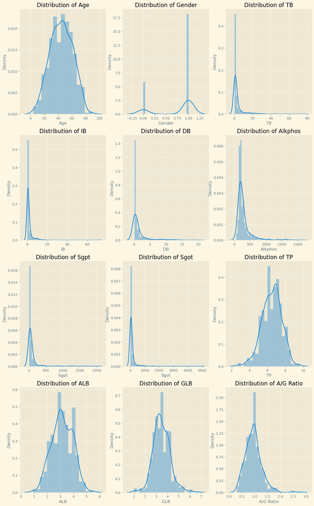

```python
fig, ax = plt.subplots(nrows = 4,ncols = 3, figsize=(15,25))
for i in range(len(ds.columns) - 1):
    plt.subplot(4, 3, i+1)
    sns.distplot(ds[ds.columns[i]])
    plt.title("Distribution of " + ds.columns[i])
```

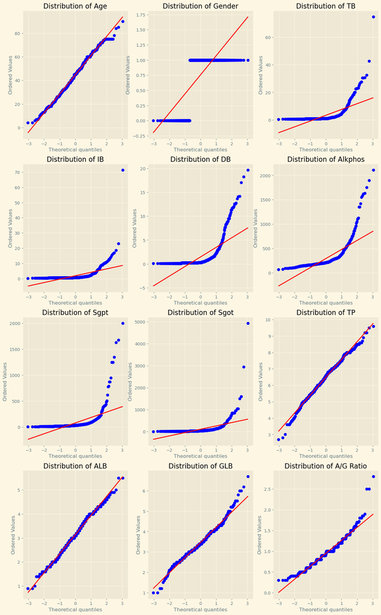

```python
fig, ax = plt.subplots(nrows = 4,ncols = 3, figsize=(15,25))
for i in range(len(ds.columns) - 1):
    plt.subplot(4, 3, i+1)
    ss.probplot(ds[ds.columns[i]], dist='norm', plot=pylab)
    plt.title("Distribution of " + ds.columns[i])
```

From the last set of plot, it looks like **Age**,**TP**,**ALB** and **GLB** are approximalely normally distributed

### Outliers

Now let's check for outliers.

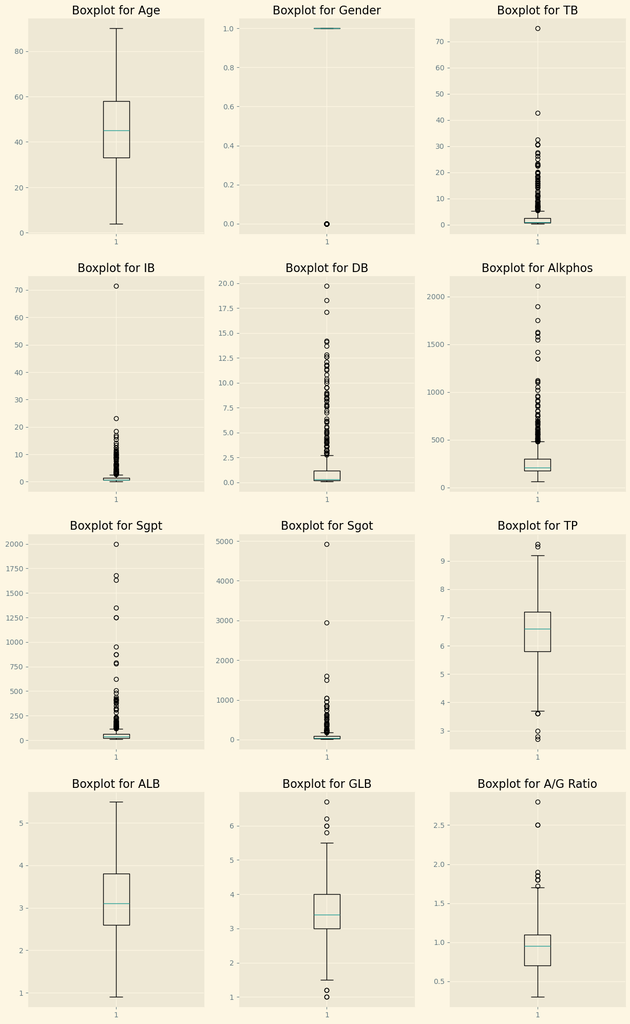

```python
fig, ax = plt.subplots(nrows = 4,ncols = 3, figsize=(15,25))
for i in range(len(ds.columns) - 1):
    plt.subplot(4, 3, i+1)
    plt.boxplot(ds[ds.columns[i]])
    plt.title("Boxplot for " + ds.columns[i])
```

The boxplot seems to confirm the high skewness nature of many variables and the normality of distribution or previously mentioned columns.

### Outliers removal

One last important step of Data Preprocessing is the removal of outliers. From theory, we know that we can use Z-score for features that are normally distributed or approximately normally distributed. We are going to use the first technique for **Age**, **TP**, **ALB**, **GLB** and **A/G Ratio**. For all the other columns, one could think that these are just highly skewed normal distribution (in such case we would use IQR Filtering for outliers), or even log normal distribution. However, testing the variables for these distribution resulted in failed tests. For example:

```python
ss.normaltest(np.log(ds["TP"]), axis=0).pvalue
```

```
3.7262606972602625e-22
```

They don't seem to resemble any familiar distribution so it's difficult to find a good way to detect and remove outliers. In fact, using IRQ filtering on the other columns would reduce the dataset of the 70%. We proceed to remove outliers only for variables that resembles a normal distribution.

```python
zscore_columns = ["Age", "TP", "ALB", "GLB", "A/G Ratio"]

for i in zscore_columns:

    upper_limit = ds[i].mean() + 3 * ds[i].std()
    lower_limit = ds[i].mean() - 3 * ds[i].std()

    ds = ds[(ds[i] <= upper_limit) & (ds[i] >= lower_limit)]
```

```python
ds.reset_index(drop=True, inplace=True)
ds
```

|  | Age | Gender | TB | IB | DB | Alkphos | Sgpt | Sgot | TP | ALB | GLB | A/G Ratio | Selector |
| --- | --- | --- | --- | --- | --- | --- | --- | --- | --- | --- | --- | --- | --- |
| 0 | 65 | 0 | 0.7 | 0.6 | 0.1 | 187 | 16 | 18 | 6.8 | 3.3 | 3.7 | 0.90 | 1 |
| 1 | 62 | 1 | 10.9 | 5.4 | 5.5 | 699 | 64 | 100 | 7.5 | 3.2 | 4.3 | 0.74 | 1 |
| 2 | 62 | 1 | 7.3 | 3.2 | 4.1 | 490 | 60 | 68 | 7.0 | 3.3 | 3.7 | 0.89 | 1 |
| 3 | 58 | 1 | 1.0 | 0.6 | 0.4 | 182 | 14 | 20 | 6.8 | 3.4 | 3.4 | 1.00 | 1 |
| 4 | 46 | 1 | 1.8 | 1.1 | 0.7 | 208 | 19 | 14 | 7.6 | 4.4 | 3.4 | 1.30 | 1 |
| ... | ... | ... | ... | ... | ... | ... | ... | ... | ... | ... | ... | ... | ... |
| 563 | 60 | 1 | 0.5 | 0.4 | 0.1 | 500 | 20 | 34 | 5.9 | 1.6 | 4.3 | 0.37 | 0 |
| 564 | 40 | 1 | 0.6 | 0.5 | 0.1 | 98 | 35 | 31 | 6.0 | 3.2 | 2.9 | 1.10 | 1 |
| 565 | 52 | 1 | 0.8 | 0.6 | 0.2 | 245 | 48 | 49 | 6.4 | 3.2 | 3.2 | 1.00 | 1 |
| 566 | 31 | 1 | 1.3 | 0.8 | 0.5 | 184 | 29 | 32 | 6.8 | 3.4 | 3.4 | 1.00 | 1 |
| 567 | 38 | 1 | 1.0 | 0.7 | 0.3 | 216 | 21 | 24 | 7.3 | 4.4 | 2.9 | 1.50 | 0 |

568 rows × 13 columns

## Data exploration

Given the fact that data came in an almost clean version, it can be interesting to dive into more data itself with some considerations on variables.

### Target variable

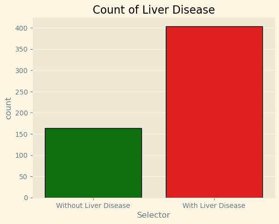

```python
sns.countplot(data = ds, x="Selector", palette = ["green", "red"], edgecolor = "black")
plt.xticks([0,1], ["Without Liver Disease", "With Liver Disease"])
plt.title("Count of Liver Disease")
```

As already mentioned, there is an important differences between the count of Liver Patients and the count of Healthy Patients. This can cause some problem during exploration, by introducing some bias on the conclusion that we can observe. One solution may be to undersample the dataset, in order to have an equal number of records with **Selector** = 1 and and records with **Selector** = 0.

```python
ds_viz = ds.copy(deep=True)

liver_patient = ds_viz[ds_viz["Selector"] == 1]
healthy_patient = ds_viz[ds_viz["Selector"] == 0]

liver_patient = liver_patient.sample(len(healthy_patient), random_state=27)
ds_viz = pd.concat([liver_patient,healthy_patient],axis=0)
```

### Relationships between variables and target variables

[output not shown]

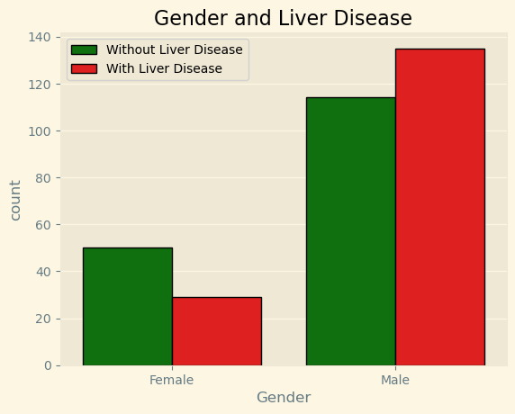

```python
ax = sns.countplot(data = ds_viz, x = "Gender", hue = "Selector", palette = ["green", "red"], edgecolor = "black")
plt.title("Gender" + " and Liver Disease")
plt.legend(["Without Liver Disease", "With Liver Disease"])
plt.xticks([0,1], ["Female", "Male"])
```

- Population of patients with **Gender** Male have a higher percentage of Liver Patients, while Female population has more Healthy Patients.

```python
ds_viz.drop("Gender", axis=1, inplace=True)
```

Let's scale numerical variables in order to have a less confusing visualization.

```python
ds_viz["Age"] = pd.cut(ds_viz["Age"], 50)
#ds_viz["TB"] = pd.cut(ds_viz["TB"], 60)
#ds_viz["IB"] = pd.cut(ds_viz["IB"], 60)
#ds_viz["DB"] = pd.cut(ds_viz["DB"], 60)
ds_viz["Alkphos"] = pd.cut(ds_viz["Alkphos"], 40)
ds_viz["Sgpt"] = pd.cut(ds_viz["Sgpt"], 60)
ds_viz["Sgot"] = pd.cut(ds_viz["Sgot"], 60)
ds_viz["TP"] = pd.cut(ds_viz["TP"], 50)
#ds_viz["ALB"] = pd.cut(ds_viz["ALB"], 50)
#ds_viz["GLB"] = pd.cut(ds_viz["GLB"], 40)
ds_viz["A/G Ratio"] = pd.cut(ds_viz["A/G Ratio"], 35)
```

```python
## This function is needed to construct a pandas.Interval starting from a String

def interval_type(s):
    """Parse interval string to Interval"""
    s = s.get_text()

    table = str.maketrans({'[': '(', ']': ')'})
    left_closed = s.startswith('[')
    right_closed = s.endswith(']')

    left, right = ast.literal_eval(s.translate(table))

    t = 'neither'
    if left_closed and right_closed:
        t = 'both'
    elif left_closed:
        t = 'left'
    elif right_closed:
        t = 'right'

    return pd.Interval(left, right, closed=t)
```

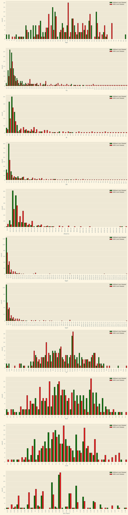

```python
fig, ax = plt.subplots(nrows = 11, ncols = 1, figsize = (15,60))
for i in range(len(ds_viz.columns) - 1):
    plt.subplot(11,1,i+1)
    ax = sns.countplot(data = ds_viz, x = ds_viz.columns[i], hue = "Selector", palette = ["green", "red"], edgecolor = "black")

    plt.legend(["Without Liver Disease", "With Liver Disease"])

    if ds_viz.columns[i] in ["Age", "Alkphos", "Sgpt", "Sgot", "TP", "A/G Ratio"]:
        old_labels = [interval_type(l) for l in ax.get_xticklabels()]
        if ds_viz.columns[i] == "Age":
            new_labels = [int((j.left + j.right) / 2) for j in old_labels]
        else:
            new_labels = [round((j.left + j.right) / 2, 2) for j in old_labels]
        ax.set_xticklabels(new_labels)
    elif ds_viz.columns[i] in ["TP", "ALB", "GLB"]:
        old_labels = [l.get_text() for l in ax.get_xticklabels()]
        new_labels = [round(float(l), 2) for l in old_labels]
        ax.set_xticklabels(new_labels)
    plt.xticks(rotation="vertical")
plt.tight_layout()
```

- Patients with **Age** between 30 and 60 year are more prone to have liver disease
- **TB** levels starting from 1.7 have a higher chance to come with Liver Disease.
- For what regards **IB**, there is a peak for values 0.5 and 0.6. However, the important insight is that, for values higher than 0.9, almost all patients suffers from Liver Disease.
- About **DB**, we have a similar behavior. In an inital range from 0.1 to 0.3 there are the highest number of Liver Patient. From 0.9 on, almost all patients suffers from Liver Disease.
- For variables **Alkphos**, **Sgpt** and **Sgot**, we have again a similar behavior. The majority of population is found at the smallest levels. From a certain values on (respectively, 266.75, 59.75, 132,98), patients suffer from Liver Disease with almost total certainty.
- For **TP** records, throughout all levels we find many cases of Liver Patients. Between 5.76 and 7.91 we have the highest concentration.
- For **ALB**, patient with levels going from 1.8 to 3.0 have more chances to suffer from Liver Disease.
- For **GLB** positive samples are found throughout the data but we have considerable peaks between 2.7 and 4.3.
- In **A/G Ratio** we can observe high probabilities of being a Liver Patients for sample between 0.41 and 0.79 levels.

### Relationships between variables and Gender variable

One of the focus of this project is to investigate the hypothesis that the prediction of Liver Disease occurences, is biased by the **Gender** of the patient. In other worlds, independent variable can have a different behavior in influencing the target variable with respect to the **Gender** of the patient. We now compare this variable of interest with all the other variables to gain more insights. Also in this case we use the dataset with balanced number of records with **Selector** = 0 and number of records with **Selector** = 1.

```python
ds_viz = ds.copy(deep=True)

liver_patient = ds_viz[ds_viz["Selector"] == 1]
healthy_patient = ds_viz[ds_viz["Selector"] == 0]

liver_patient = liver_patient.sample(len(healthy_patient), random_state=27)
ds_viz = pd.concat([liver_patient,healthy_patient],axis=0)
```

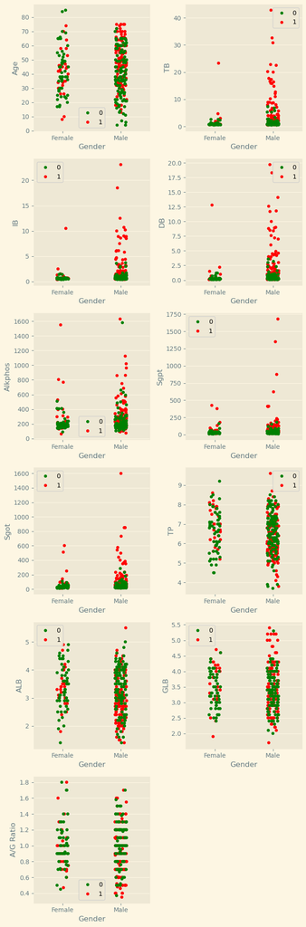

```python
variables = ds_viz.drop("Gender", axis = 1).columns

fig, ax = plt.subplots(nrows = 6,ncols = 2,figsize = (7, 21))
fig.delaxes(ax[5,1])

for i in range(len(variables) - 1):
    plt.subplot(6,2,i+1)
    sns.stripplot(data = ds_viz, x = "Gender",y = variables[i], hue = "Selector", palette = ["green", "red"])
    plt.legend()
    plt.xticks([0,1], ["Female", "Male"])
plt.tight_layout()
```

Despite imbalance in the number of Males and Females we can observe few things:

- While Males suffers of Liver Disease throughout all **Age**s, Females that are Liver Patient are found the most between **Age** of 30 and 60.
- For what regards **TB**, **IB** and **DB**, Males and Females present the same kind of behavior.
- About **Sgpt** and **Sgot** variables, Males tend to have high anomaly values more that Female. Such high anomaly values always come with Liver Disease.
- Males displays Liver Disease in a similar way for all levels of **TP** and **ALB**. On the other hand, for Females, we have ranges of **ALB** more affected by Liver Diseases, while for **TP** we have no particular behavior.
- For **GLB**, in Male population we have Liver Patients thorughtout all data and, for levels above 4, almost a totality of positive patients.
- For A/G Ratio, we have no particular insights.

In order to come to bold conclusions we'd need a higher amount of data. However, we can observe how some indicators present the same behavior for both **Gender**s, some other indicators presents a particular behavior for just one of the two.

### Correlations

Last but not least, in this Exploration phase we also want to check for possible correlations between the variables of this dataset.

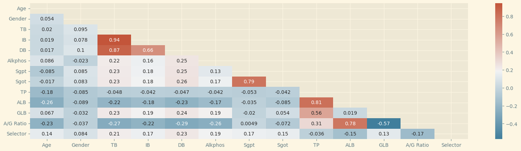

```python
corr = ds.corr()
matrix = np.triu(corr)
cmap = sns.diverging_palette(230, 20, as_cmap=True)

plt.figure(figsize = (20,5))
sns.heatmap(corr, annot = True, mask = matrix, cmap=cmap);
```

- As we can expect there is a strong correlation between **TB** and **DB**, **IB**, since **TB** = **DB** + **IB**.
- Similarly, **TP** and **A/G Ratio** are highly correlated with **ALB** and **GLB**.
- Correlation between **Sgpt** and **Sgot** is also worth mentioning.

Let's focus on the correlations between the variables and the target variable **Selector**.

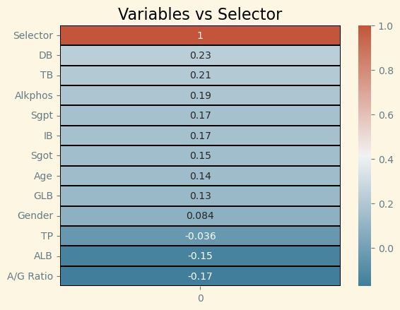

```python
correlation = ds.corrwith(ds["Selector"], method="pearson").sort_values(ascending = False).to_frame()
sns.heatmap(correlation, annot = True, linewidths = 0.1,linecolor = 'black',cmap=cmap);
plt.title("Variables vs Selector");
```

- **Gender** and **TP** have an almost null correlation with the target.
- The other variables seems to have an either positive or negative low correlation with **Selector**.

## Feature selection

Feature selection is the process of reducing the number of input variables when developing a predictive model. It is desirable to reduce the number of input variables to both reduce the computational cost of modeling and, in some cases, to improve the performance of the model. In our case, we choose to select a subset of feature, by considering the first 5 with highest correlation with **Selector**. We decide to do so not for a matter of high dimensionality but because, in general, the correlation scores with **Selector** are not astonishing (avg. correlation score = 0.15). By keeping only the features with correlation score higher that the avg, we hope to bring out the best of this dataset.

### Scaling

First of all, since many ML algorithms are sensitive to the scale of data, we need to adopt scaling techniques on our feature . Given the characteristics of the features, we may apply different scaling techniques: for example, in our dataset we have some variables that are normally distributed and others that are not. We should use Robust Scaling for those that are not normally distributed with a strong skewness and use Standardization for those that are already normally distributed. In particular, with Robust Scaling the median is removed and data are scaled according to the quantile range. Standardization, instead, centers data around a mean of 0 and a standard deviation of 1.

```python
robust_scaler = RobustScaler()
standard_scaler = StandardScaler()

ds["TB"] = robust_scaler.fit_transform(ds[["TB"]])
ds["IB"] = robust_scaler.fit_transform(ds[["IB"]])
ds["DB"] = robust_scaler.fit_transform(ds[["DB"]])
ds["Alkphos"] = robust_scaler.fit_transform(ds[["Alkphos"]])
ds["Sgpt"] = robust_scaler.fit_transform(ds[["Sgpt"]])
ds["Sgot"] = robust_scaler.fit_transform(ds[["Sgot"]])
ds["A/G Ratio"] = robust_scaler.fit_transform(ds[["A/G Ratio"]])

ds["Age"] = standard_scaler.fit_transform(ds[['Age']])
ds["TP"] = standard_scaler.fit_transform(ds[["TP"]])
ds["ALB"] = standard_scaler.fit_transform(ds[["ALB"]])
ds["GLB"] = standard_scaler.fit_transform(ds[["GLB"]])
```

### ANOVA correlation coefficient

If we don't take into account **Gender** variable, this problem is a classification problem with variables of numerical type and a target variable of binary type. In this case, it makes sense to use ANOVA correlation coefficient in order to discover the most meaningful features to take into account. First of all, we extract the target variable.

```python
sampleData_Y = ds[["Selector"]]
sampleData_Y.head()
```

|  | Selector |
| --- | --- |
| 0 | 1 |
| 1 | 1 |
| 2 | 1 |
| 3 | 1 |
| 4 | 1 |

Now we extract the other variables that we want to test.

```python
sampleData_X  = ds.loc[:,"Age":"A/G Ratio"]
sampleData_X.head()
```

|  | Age | Gender | TB | IB | DB | Alkphos | Sgpt | Sgot | TP | ALB | GLB | A/G Ratio |
| --- | --- | --- | --- | --- | --- | --- | --- | --- | --- | --- | --- | --- |
| 0 | 1.265573 | 0 | -0.1875 | -0.142857 | -0.2 | -0.172131 | -0.500000 | -0.388186 | 0.290744 | 0.180954 | 0.334183 | -0.075 |
| 1 | 1.079521 | 1 | 6.1875 | 6.714286 | 5.2 | 4.024590 | 0.763158 | 0.995781 | 0.957408 | 0.053749 | 1.233073 | -0.475 |
| 2 | 1.079521 | 1 | 3.9375 | 3.571429 | 3.8 | 2.311475 | 0.657895 | 0.455696 | 0.481219 | 0.180954 | 0.334183 | -0.100 |
| 3 | 0.831450 | 1 | 0.0000 | -0.142857 | 0.1 | -0.213115 | -0.552632 | -0.354430 | 0.290744 | 0.308159 | -0.115263 | 0.175 |
| 4 | 0.087239 | 1 | 0.5000 | 0.571429 | 0.4 | 0.000000 | -0.421053 | -0.455696 | 1.052646 | 1.580210 | -0.115263 | 0.925 |

And now we test.

```python
k = 5

selector = SelectKBest(f_classif, k=k)

selector.fit(sampleData_X, sampleData_Y)

best_feats = selector.get_support(indices=True)

ds_best = sampleData_X.iloc[:,best_feats]

ds_best.head()
```

|  | TB | DB | Alkphos | Sgpt | A/G Ratio |
| --- | --- | --- | --- | --- | --- |
| 0 | -0.1875 | -0.2 | -0.172131 | -0.500000 | -0.075 |
| 1 | 6.1875 | 5.2 | 4.024590 | 0.763158 | -0.475 |
| 2 | 3.9375 | 3.8 | 2.311475 | 0.657895 | -0.100 |
| 3 | 0.0000 | 0.1 | -0.213115 | -0.552632 | 0.175 |
| 4 | 0.5000 | 0.4 | 0.000000 | -0.421053 | 0.925 |

**TB** is highly correlated with both **IB** and **DB**. **IB** and **DB** themselves are higly correlated as well. We can try to remove **DB** and see what happens.

```python
sampleData_X  = sampleData_X.drop(["DB"], axis=1)
sampleData_X.head()
```

|  | Age | Gender | TB | IB | Alkphos | Sgpt | Sgot | TP | ALB | GLB | A/G Ratio |
| --- | --- | --- | --- | --- | --- | --- | --- | --- | --- | --- | --- |
| 0 | 1.265573 | 0 | -0.1875 | -0.142857 | -0.172131 | -0.500000 | -0.388186 | 0.290744 | 0.180954 | 0.334183 | -0.075 |
| 1 | 1.079521 | 1 | 6.1875 | 6.714286 | 4.024590 | 0.763158 | 0.995781 | 0.957408 | 0.053749 | 1.233073 | -0.475 |
| 2 | 1.079521 | 1 | 3.9375 | 3.571429 | 2.311475 | 0.657895 | 0.455696 | 0.481219 | 0.180954 | 0.334183 | -0.100 |
| 3 | 0.831450 | 1 | 0.0000 | -0.142857 | -0.213115 | -0.552632 | -0.354430 | 0.290744 | 0.308159 | -0.115263 | 0.175 |
| 4 | 0.087239 | 1 | 0.5000 | 0.571429 | 0.000000 | -0.421053 | -0.455696 | 1.052646 | 1.580210 | -0.115263 | 0.925 |

```python
k = 5

selector2 = SelectKBest(f_classif, k=k)

selector2.fit(sampleData_X, sampleData_Y)

best_feats2 = selector2.get_support(indices=True)

ds_best2 = sampleData_X.iloc[:,best_feats2]

ds_best2.head()
```

|  | TB | IB | Alkphos | Sgpt | A/G Ratio |
| --- | --- | --- | --- | --- | --- |
| 0 | -0.1875 | -0.142857 | -0.172131 | -0.500000 | -0.075 |
| 1 | 6.1875 | 6.714286 | 4.024590 | 0.763158 | -0.475 |
| 2 | 3.9375 | 3.571429 | 2.311475 | 0.657895 | -0.100 |
| 3 | 0.0000 | -0.142857 | -0.213115 | -0.552632 | 0.175 |
| 4 | 0.5000 | 0.571429 | 0.000000 | -0.421053 | 0.925 |

Instead of **DB**, **IB** is appeared as one of the best features. However, it is even more correlated to **TB** than **DB** and with an even less score. So we are going to keep **DB** instead of **IB**.

The features selected does not present very high correlation between each other (except for **TB** and **DB**), so one can expect they are informative. This seems a good starting point to dive into actual classification task. Later we can try to use a different number and selection of features and see what choice is best.

### Let's try PCA

As an alternative way to select the best features, we can try PCA.

```python
sampleData_X_pca  = ds.loc[:,"Age":"A/G Ratio"]

pca = PCA(n_components = 4)
fit = pca.fit(sampleData_X_pca)

print("Explained Variance: %s" % fit.explained_variance_ratio_)
```

```
Explained Variance: [0.51659565 0.3250871  0.04734666 0.04032153]
```

```python
sampleData_X_pca  = ds.loc[:,"Age":"A/G Ratio"]

pca = PCA(n_components = 4)
fit = pca.fit(sampleData_X_pca)

print("Explained Variance: %s" % fit.explained_variance_ratio_)
```

```
Explained Variance: [0.51659565 0.3250871  0.04734666 0.04032153]
```

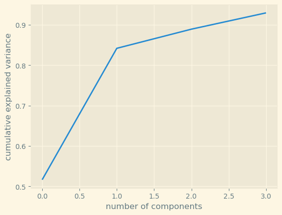

```python
plt.plot(np.cumsum(pca.explained_variance_ratio_))
plt.xlabel('number of components')
plt.ylabel('cumulative explained variance');
```

```python
pca = PCA(3).fit(sampleData_X_pca)
components = pca.transform(sampleData_X_pca)
projected = pca.inverse_transform(components)
```

```python
projected
```

```
array([[ 3.90128221e-03,  7.29107630e-01, -4.37394409e-02, ...,
         8.75341076e-02, -7.83480612e-02,  9.25274056e-02],
       [ 1.92320108e-01,  7.83652368e-01,  5.72508484e+00, ...,
        -3.98999686e-01,  4.54183829e-01, -3.69425543e-01],
       [ 1.02139184e-01,  7.63951301e-01,  3.43547524e+00, ...,
        -1.93704279e-01,  2.25936833e-01, -1.71643379e-01],
       ...,
       [-1.97190286e-02,  7.34559588e-01, -5.00956683e-03, ...,
         9.82851130e-02, -9.93188997e-02,  1.09382237e-01],
       [-1.95618764e-02,  7.34087486e-01,  2.18444988e-01, ...,
         9.53271276e-02, -9.14655100e-02,  1.04252454e-01],
       [-2.99025921e-02,  7.31583452e-01,  2.06540738e-02, ...,
         1.18380813e-01, -1.15573472e-01,  1.25685909e-01]])
```

## Classification

It's time to actually apply Classification Algorithms to try to predict of variable of interest. For what concerns Binary Classification, there are many techniques that can be adopted: K-NN, Naive Bayes, Logistic Regression, Decision Tree, SVM. We are going to try out some of these methods and compare the respective results.

```python
X = ds_best
y = sampleData_Y
```

### Cross-validation procedure

First of all, we need to spend a couple of world for the Model Validation. We know that the simplest model evaluation procedure is to split a dataset into two parts and use one part for training a model and the second part for testing the model. As such, the parts of the dataset are named for their function, train set and test set respectively.

This is effective if our collected dataset is very large and representative of the problem. In reality, we rarely have enough data to get an unbiased estimate of performance using a train/test split evaluation of a model. It is a much better idea to split the datase in more than just 2 folds. That's why we are going to use k-fold Cross-validation to prepare our training set and test set.

However, we have to keep in mind that our dataset is imbalanced with respect to the target variable **Selector**. That's why simple k-fold Cross-validation is not enough. We have to use STRATIFIED k-fold Cross-validation. In this way, we are sure that the sampling of the folds will take into account the imbalance of data and will enforce the class distribution in each split of the data to match the distribution in the complete training dataset.

Here we see how the distribution is mantained for each one of the 10 splits.

```python
kfold = StratifiedKFold(n_splits=10, shuffle=True, random_state=1)

for train_ix, test_ix in kfold.split(X, y):

    train_X, test_X = X.loc[train_ix], X.loc[test_ix]
    train_y, test_y = y.loc[train_ix], y.loc[test_ix]

    train_0, train_1 = len(train_y[train_y["Selector"] == 0]), len(train_y[train_y["Selector"] == 1])
    test_0, test_1 = len(test_y[test_y["Selector"] == 0]), len(test_y[test_y["Selector"] == 1])

    print("> Train: 0={0}, 1={1}, Test: 0={2}, 1={3}".format(train_0, train_1, test_0, test_1))
```

```
> Train: 0=148, 1=363, Test: 0=16, 1=41
> Train: 0=148, 1=363, Test: 0=16, 1=41
> Train: 0=148, 1=363, Test: 0=16, 1=41
> Train: 0=148, 1=363, Test: 0=16, 1=41
> Train: 0=147, 1=364, Test: 0=17, 1=40
> Train: 0=147, 1=364, Test: 0=17, 1=40
> Train: 0=147, 1=364, Test: 0=17, 1=40
> Train: 0=147, 1=364, Test: 0=17, 1=40
> Train: 0=148, 1=364, Test: 0=16, 1=40
> Train: 0=148, 1=364, Test: 0=16, 1=40
```

### Train Test Split

In order to test the output of the classifier, we split the data into a training and testing set, keeping in mind once again that out data are imbalanced with respect to **Selector**.

```python
X_train, X_test, y_train, y_test = train_test_split(X, y, stratify=y, test_size=0.25, random_state=27)
```

We define a function *model_evaluation* to train the model and apply it to the test set. It also shows the classification report, the precision-recall curve and the confusion matrix. To be point out, Precision-Recall curve should be used in a context where there is class imbalance. ROC generallly present an optimistic picture of the model on datasets with a class imbalance so in our case it could be deceptive and lead to incorrect interpretations of the model skill. In both curves, generally AUC is used as practical metric to compare different models.

```python
# This function plots the Precision-Recall curve and computes the Area Under Curve. By default PR Curve for a No skilled classifier
# is plotted to immediately check if our model perfoms, at least better than that. In particular, a classifier with no skill is a
# classifier that always a random class or a constant class in all cases.

def my_pr_curve(model):

    dummy = DummyClassifier(strategy='stratified')
    dummy.fit(X_train, y_train)
    yhat = dummy.predict_proba(X_test)
    pos_probs = yhat[:, 1]
    precision, recall, _ = precision_recall_curve(y_test, pos_probs)
    auc_score = auc(recall, precision)
    print('No Skill PR AUC: %.3f' % auc_score)

    yhat = model.predict_proba(X_test)
    pos_probs = yhat[:, 1]
    precision, recall, _ = precision_recall_curve(y_test, pos_probs)
    auc_score = auc(recall, precision)
    print('Model PR AUC: %.3f' % auc_score)

    no_skill = len(y[y["Selector"]==1]) / len(y)
    plt.plot([0, 1], [no_skill, no_skill], linestyle='--', label='No Skill')
    plt.plot(recall, precision, marker='.', label='Model')
    plt.xlabel('Recall')
    plt.ylabel('Precision')
    plt.legend()
    plt.show()
```

```python
# This function plots the ROC curve and computes the Area Under Curve of ROC curve. By default ROC curve for a Random
# classifier is plotted to immediately check if our model performs, at least, better than that.

def my_roc(model):

    dummy = DummyClassifier(strategy='stratified')
    dummy.fit(X_train, y_train)
    yhat = dummy.predict_proba(X_test)
    pos_probs = yhat[:, 1]
    roc_auc = roc_auc_score(y_test, pos_probs)
    print('No Skill ROC AUC %.3f' % roc_auc)

    yhat = model.predict_proba(X_test)
    pos_probs = yhat[:, 1]
    roc_auc = roc_auc_score(y_test, pos_probs)
    print('Model ROC AUC %.3f' % roc_auc)

    plt.plot([0, 1], [0, 1], linestyle='--', label='No Skill')
    fpr, tpr, _ = roc_curve(y_test, pos_probs)

    plt.plot(fpr, tpr, marker='.', label='Model')
    plt.xlabel('False Positive Rate')
    plt.ylabel('True Positive Rate')
    plt.legend()
    plt.show()
```

```python
# This function applies Grid Search to find the best hyperparameters. Within Grid Search, 10-fold cross validation is used as
# splitting strategy. By defaulf parameter refit of GridSearchCV function is set to True. This means that, in the end, the estimator
# is refit on training data using the best found parameters on the whole dataset.

def model_evaluation(mdl, parameters, cv, scoring="accuracy"):

    clf = GridSearchCV(mdl,                    # model
                   param_grid = parameters,   # hyperparameters
                   scoring=scoring,           # metric for scoring
                   cv=cv)                     # number of folds

    clf.fit(X_train,y_train)

    print("Results of Training")
    print("-----------------------------------")
    print("Tuned Hyperparameters :", clf.best_params_)
    print("Accuracy :",clf.best_score_)
    print("-----------------------------------\n")

    model = clf.best_estimator_
    y_fit = model.predict(X_test)
    #y_scores = model.decision_function(X_test)

    print("Report after Predictions")
    print(classification_report(y_test, y_fit, target_names=["Without Liver Disease", "With Liver Disease"]))

    my_roc(model)
    my_pr_curve(model)

    mat = confusion_matrix(y_test, y_fit)
    sns.heatmap(mat.T, square=True, annot=True, fmt='d', cbar=False,
                xticklabels=["Without Liver Disease", "With Liver Disease"],
                yticklabels=["Without Liver Disease", "With Liver Disease"])
    plt.xlabel('true label')
    plt.ylabel('predicted label')

    return y_fit
```

### Logistic Regression

Let's try with this first well-known method for binary classification. As anticipated, we are going to use a Stratified K-Fold for evaluation and Hyperparameter search. GridSearchCV comes in help.

```python
cv = RepeatedStratifiedKFold(n_splits = 10,n_repeats = 10,random_state = 27)
```

```
Results of Training
-----------------------------------
Tuned Hyperparameters : {'C': 0.01, 'penalty': 'l2', 'solver': 'liblinear'}
Accuracy : 0.7164341085271319
-----------------------------------

Report after Predictions
                       precision    recall  f1-score   support

Without Liver Disease       0.33      0.05      0.09        41
   With Liver Disease       0.71      0.96      0.82       101

             accuracy                           0.70       142
            macro avg       0.52      0.50      0.45       142
         weighted avg       0.60      0.70      0.61       142

No Skill ROC AUC 0.479
Model ROC AUC 0.723
```

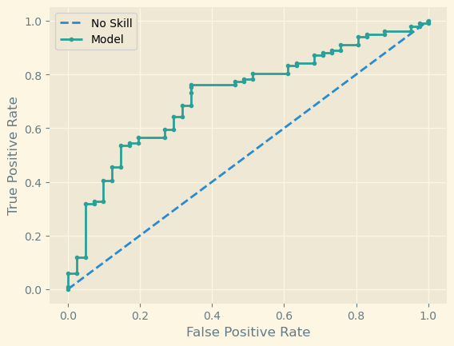

```
No Skill PR AUC: 0.804
Model PR AUC: 0.860
```

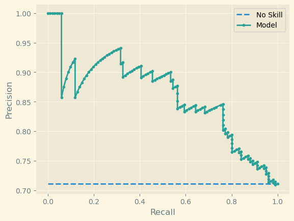

```
array([1, 1, 1, 1, 1, 1, 0, 0, 1, 1, 1, 1, 1, 1, 1, 1, 1, 1, 1, 1, 1, 1,
       1, 1, 1, 1, 1, 1, 1, 1, 1, 1, 1, 1, 1, 0, 1, 1, 1, 1, 1, 1, 1, 1,
       1, 1, 1, 1, 1, 1, 1, 1, 0, 1, 1, 1, 1, 1, 1, 1, 1, 1, 1, 1, 1, 1,
       1, 1, 1, 1, 1, 1, 1, 1, 1, 1, 1, 1, 1, 1, 1, 1, 1, 1, 1, 1, 1, 1,
       1, 1, 1, 1, 1, 1, 1, 1, 1, 1, 1, 1, 1, 1, 1, 1, 1, 1, 1, 1, 1, 1,
       1, 1, 1, 1, 1, 1, 1, 1, 1, 1, 1, 1, 1, 1, 1, 1, 1, 1, 1, 1, 1, 1,
       1, 0, 0, 1, 1, 1, 1, 1, 1, 1], dtype=int64)
```

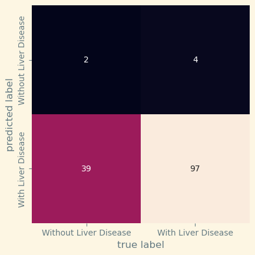

```python
lr = LogisticRegression()

parameters = {
    'penalty' : ['l1','l2'],
    'C'       : np.logspace(-3,3,7),
    'solver'  : ['newton-cg', 'lbfgs', 'liblinear']
}

model_evaluation(lr, parameters, cv)
```

Despite the high accuracy, this models perform terribly bad. As we can notice, it just predicts almost everything to be 1 (With Liver Disease). This is not the behavior we are searching or expecting, ever more so after being so cautios about taking into account imbalance in data. However, there is one thing we can try: we can add the parameter class_weight set to *balanced*. Doing so the model uses the values of the target to automatically adjust weights inversely proportional to class frequencies in the input data. Then, the model learns that, even if class (Without Liver Disease) is less frequent, it still needs to learn how to recognize that class. We also try other combination of weights.

Here we try F1_score as scoring modality for GridSearchCV, the harmonic mean of precision and recall. It provides a balance between precision and recall and is especially useful when the class distribution is imbalanced. However, F1_score is biased towards all, except True Negative and our goal is to improve the results by obtaining a Classifier that is not trivial and can also classifies Negative labels correctely. To address this, we use a version where the F1 score of each class label is taken and the average between the two is computed. (F1-score for negative class is the default formula with TN instead of TP.)

```
Results of Training
-----------------------------------
Tuned Hyperparameters : {'C': 0.001, 'class_weight': {0: 60, 1: 40}, 'penalty': 'l2', 'solver': 'newton-cg'}
Accuracy : 0.6483834790363019
-----------------------------------

Report after Predictions
                       precision    recall  f1-score   support

Without Liver Disease       0.49      0.59      0.53        41
   With Liver Disease       0.82      0.75      0.78       101

             accuracy                           0.70       142
            macro avg       0.65      0.67      0.66       142
         weighted avg       0.72      0.70      0.71       142

No Skill ROC AUC 0.520
Model ROC AUC 0.726
```

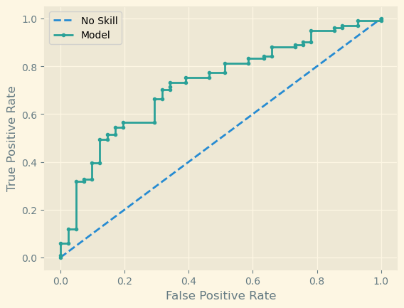

```
No Skill PR AUC: 0.798
Model PR AUC: 0.860
```

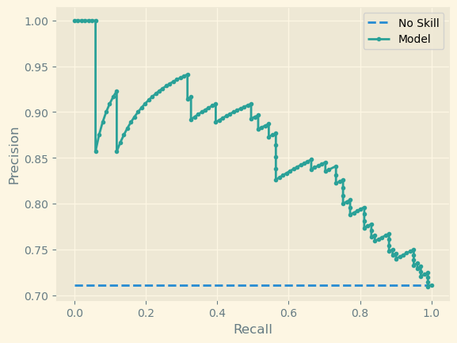

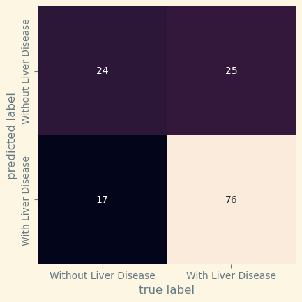

```python
parameters = {
    'penalty' : ['l1','l2'],
    'C'       : np.logspace(-3,3,7),
    'solver'  : ['newton-cg', 'lbfgs', 'liblinear'],
    'class_weight' : ['balanced', {0: 55, 1: 45}, {0: 60, 1: 40}, {0: 100, 1: 10}, {0: 70, 1: 30}]
}

result = model_evaluation(lr, parameters, cv, "f1_macro")
```

With respect to ROC AUC, we have a slight improvement, while PR Curve AUC is the same. However, the confusion matrix better shows how this last model is not just predicting everything to be the same, despite having a lower number of True Positive. In fact, averaged F1_score is 0.45 for the first one and 0.66 for the second one.

Let's now try with some other classifiers:

### Support Vector Machine

We try with Support Vector Machine to see if we can achieve better.

```
Results of Training
-----------------------------------
Tuned Hyperparameters : {'C': 0.1, 'class_weight': {0: 100, 1: 10}, 'gamma': 5, 'kernel': 'rbf', 'probability': True}
Accuracy : 0.6722038308848549
-----------------------------------

Report after Predictions
                       precision    recall  f1-score   support

Without Liver Disease       0.46      0.66      0.54        41
   With Liver Disease       0.83      0.68      0.75       101

             accuracy                           0.68       142
            macro avg       0.64      0.67      0.65       142
         weighted avg       0.72      0.68      0.69       142

No Skill ROC AUC 0.529
Model ROC AUC 0.742
```

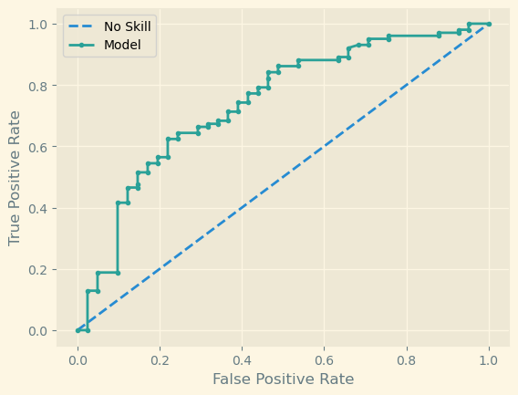

```
No Skill PR AUC: 0.818
Model PR AUC: 0.840
```

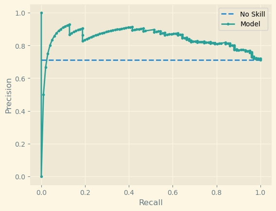

```
array([1, 1, 1, 0, 0, 1, 0, 1, 1, 1, 1, 1, 1, 1, 1, 1, 0, 0, 0, 0, 0, 0,
       0, 1, 0, 0, 1, 0, 1, 1, 1, 0, 1, 1, 0, 0, 1, 1, 0, 1, 0, 1, 1, 1,
       1, 1, 1, 1, 0, 1, 1, 0, 0, 1, 0, 0, 1, 1, 1, 1, 1, 1, 1, 1, 0, 0,
       1, 1, 0, 1, 1, 0, 1, 1, 0, 0, 0, 1, 1, 1, 1, 0, 0, 1, 0, 0, 0, 1,
       1, 1, 1, 0, 1, 0, 0, 0, 1, 1, 0, 0, 1, 1, 1, 1, 0, 0, 1, 1, 0, 1,
       1, 1, 1, 0, 1, 1, 0, 1, 0, 0, 1, 1, 0, 1, 1, 1, 1, 0, 1, 0, 0, 0,
       0, 0, 0, 1, 1, 1, 0, 1, 0, 0], dtype=int64)
```

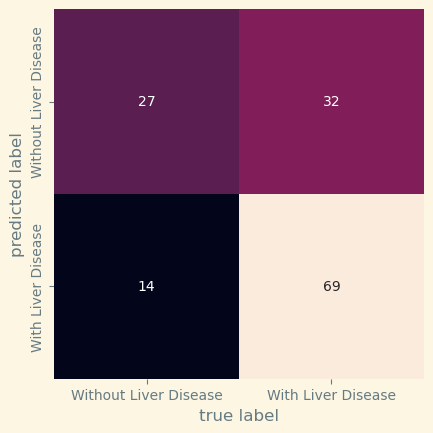

```python
svm = SVC()
"""parameters = {'C': [0.1, 1, 10, 100, 1000],
              'gamma': [1, 0.1, 0.01, 0.001, 0.0001],
              'kernel': ['rbf', 'polynomial', 'sigmoid'],
              'class_weight': ['balanced', {0: 55, 1: 45}, {0: 60, 1: 40}, {0: 100, 1: 10}, {0: 70, 1: 30}],
              'probability': [True]}"""

parameters = {'C': [0.1, 1, 10, 100],
              'gamma': [5, 1, 0.1, 0.01, 0.001],
              'kernel': ['rbf', 'sigmoid'],
              'class_weight': ['balanced', {0: 55, 1: 45}, {0: 60, 1: 40}, {0: 100, 1: 10}, {0: 70, 1: 30}],
              'probability': [True]}

model_evaluation(svm, parameters, cv, "f1_macro")
```

### Decision Tree

```
Results of Training
-----------------------------------
Tuned Hyperparameters : {'class_weight': {0: 60, 1: 40}, 'criterion': 'gini', 'max_depth': 3, 'min_samples_leaf': 3, 'min_samples_split': 2}
Accuracy : 0.6430824735481748
-----------------------------------

Report after Predictions
                       precision    recall  f1-score   support

Without Liver Disease       0.39      0.59      0.47        41
   With Liver Disease       0.79      0.62      0.70       101

             accuracy                           0.61       142
            macro avg       0.59      0.60      0.58       142
         weighted avg       0.67      0.61      0.63       142

No Skill ROC AUC 0.525
Model ROC AUC 0.631
```

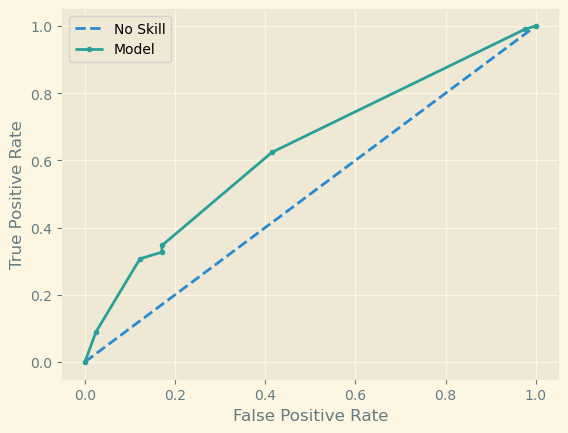

```
No Skill PR AUC: 0.793
Model PR AUC: 0.816
```

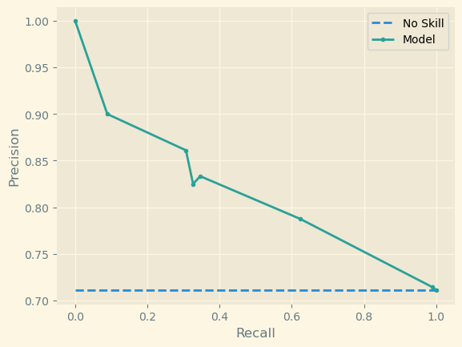

```
array([1, 1, 1, 1, 0, 1, 0, 0, 1, 1, 1, 1, 1, 1, 1, 1, 0, 0, 0, 0, 0, 1,
       0, 1, 0, 0, 1, 1, 1, 1, 0, 0, 0, 0, 0, 0, 1, 0, 1, 1, 1, 1, 1, 1,
       0, 0, 1, 1, 0, 1, 0, 1, 0, 1, 0, 0, 1, 1, 1, 1, 1, 1, 1, 1, 0, 0,
       0, 1, 1, 1, 1, 1, 1, 1, 0, 0, 0, 1, 1, 0, 1, 0, 0, 1, 0, 0, 0, 1,
       0, 1, 1, 1, 1, 1, 0, 0, 1, 0, 0, 0, 1, 1, 1, 1, 1, 1, 0, 1, 0, 0,
       1, 1, 1, 0, 1, 1, 0, 1, 0, 0, 0, 1, 0, 0, 0, 1, 1, 0, 1, 1, 0, 1,
       0, 1, 0, 1, 1, 0, 0, 1, 0, 0], dtype=int64)
```

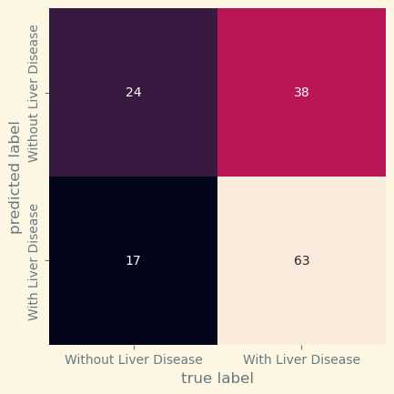

```python
dt = DecisionTreeClassifier(random_state=123)

parameters =  {
    'criterion': ['gini', 'entropy', 'log_loss'],
    'min_samples_leaf': [1, 2, 3],
    'min_samples_split': [1, 2, 3],
    'max_depth': [1, 2, 3, 4, 5, 6],
    'class_weight': ['balanced', {0: 55, 1: 45}, {0: 60, 1: 40}, {0: 100, 1: 10}, {0: 70, 1: 30}]
}

model_evaluation(dt, parameters, cv, "f1_macro")
```

Metrics and Confusion Matrix suggest us that Decision Tree is not a better choice for this problem with respect to the already seen models, even if we performed Feature Selection (useful when it comes to use Decision Trees). The number of False Negative is even higher than the SVM model.

### K-Nearest Neighbors

As last model, we try K-NN, particularly useful for Binary Classification, given its semplicity. When a data point is provided to the algorithm, with a given value of K, it searches for the K nearest neighbors to that data point. The nearest neighbors are found by calculating the distance between the given data point and the data points in the initial dataset. Once K nearest neighbors are identified, the KNN algorithm next determines the majority of neighbors belong to which class.

[output not shown]

```
Results of Training
-----------------------------------
Tuned Hyperparameters : {'algorithm': 'ball_tree', 'metric': 'minkowski', 'n_neighbors': 4, 'weights': 'uniform'}
Accuracy : 0.6380004118157312
-----------------------------------

Report after Predictions
                       precision    recall  f1-score   support

Without Liver Disease       0.42      0.54      0.47        41
   With Liver Disease       0.79      0.69      0.74       101

             accuracy                           0.65       142
            macro avg       0.60      0.61      0.60       142
         weighted avg       0.68      0.65      0.66       142

No Skill ROC AUC 0.505
Model ROC AUC 0.665
```

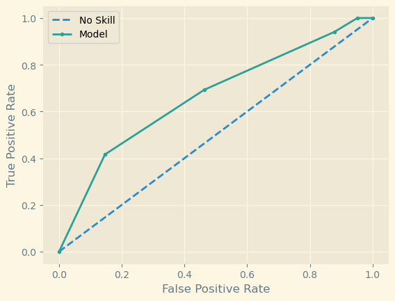

```
No Skill PR AUC: 0.791
Model PR AUC: 0.850
```

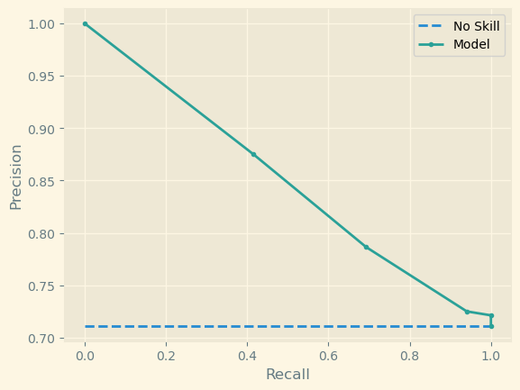

```
array([1, 1, 1, 1, 0, 1, 1, 0, 1, 1, 1, 0, 1, 1, 1, 1, 0, 0, 0, 0, 0, 0,
       0, 1, 1, 1, 1, 1, 1, 1, 1, 0, 0, 1, 0, 0, 1, 1, 0, 1, 1, 0, 0, 1,
       1, 0, 1, 1, 0, 1, 0, 0, 0, 1, 0, 1, 1, 1, 1, 1, 1, 1, 1, 1, 0, 1,
       1, 1, 1, 1, 1, 0, 1, 1, 1, 0, 0, 1, 1, 1, 1, 0, 1, 1, 0, 1, 0, 1,
       0, 0, 1, 0, 1, 0, 1, 0, 1, 0, 1, 1, 1, 0, 0, 1, 0, 0, 1, 1, 0, 1,
       1, 1, 1, 0, 1, 1, 0, 1, 0, 0, 1, 1, 1, 1, 1, 1, 1, 0, 1, 0, 1, 0,
       0, 0, 0, 1, 1, 1, 0, 1, 0, 1], dtype=int64)
```

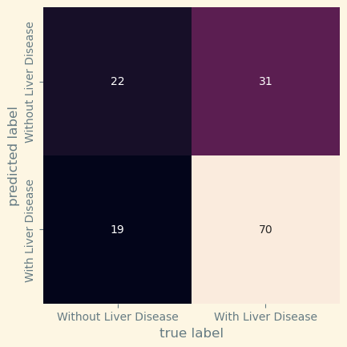

```python
knn = KNeighborsClassifier()

parameters = {
    'n_neighbors': range(1,11),
    'metric': ['minkowski', 'euclidean', 'manhattan'],
    'weights': ['uniform', 'distance'],
    'algorithm': ['auto', 'ball_tree', 'kd_tree', 'brute']
}

model_evaluation(knn, parameters, cv, "f1_macro")
```

This models performs worse in terms of metrics with respect to Logistic Regression and SVC. If anything, it is more similar to how Logistic Regression performed, keeping a higer Precision for Positive Label. One thing that we can try is the following: given that K-NN has no parameters to manage class weights and therefore it doesn't account for class imbalance, we can try to adopt oversampling.

```python
def model_evaluation_ovr(model, parameters, cv, scoring="accuracy"):

    clf = GridSearchCV(model,                    # model
                   param_grid = parameters,   # hyperparameters
                   scoring=scoring,           # metric for scoring
                   cv=cv)                     # number of folds

    steps = [('over', RandomOverSampler(sampling_strategy=0.7)), ('model', clf)]
    pipeline = Pipeline(steps=steps)

    pipeline.fit(X_train,y_train)

    #print("Tuned Hyperparameters :", pipeline.best_params_)
    #print("Accuracy :",pipeline.best_score_)

    #model = pipeline.best_estimator_
    y_fit = pipeline.predict(X_test)
    #y_scores = pipeline.decision_function(X_test)

    print(classification_report(y_test, y_fit, target_names=["Without Liver Disease", "With Liver Disease"]))

    my_roc(pipeline)
    my_pr_curve(pipeline)

    mat = confusion_matrix(y_test, y_fit)
    sns.heatmap(mat.T, square=True, annot=True, fmt='d', cbar=False,
                xticklabels=["Without Liver Disease", "With Liver Disease"],
                yticklabels=["Without Liver Disease", "With Liver Disease"])
    plt.xlabel('true label')
    plt.ylabel('predicted label')
```

```
                       precision    recall  f1-score   support

Without Liver Disease       0.45      0.59      0.51        41
   With Liver Disease       0.81      0.71      0.76       101

             accuracy                           0.68       142
            macro avg       0.63      0.65      0.63       142
         weighted avg       0.71      0.68      0.69       142

No Skill ROC AUC 0.476
Model ROC AUC 0.720
```

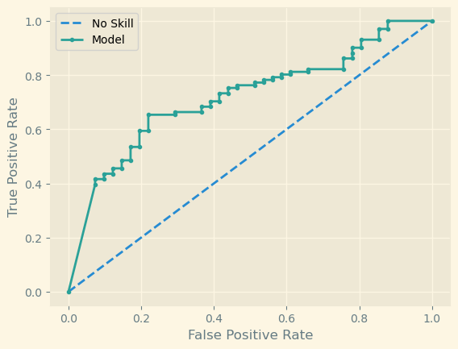

```
No Skill PR AUC: 0.829
Model PR AUC: 0.876
```

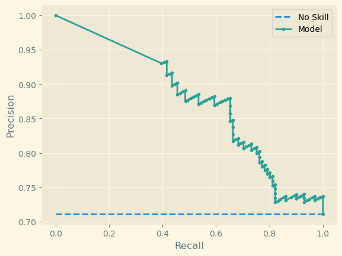

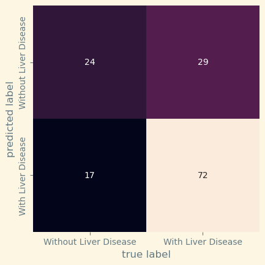

```python
model_evaluation_ovr(knn, parameters, cv, "f1_macro")
```

Such model has the best value for PR Curve AUC, the most useful metric in situations where there is class imbalance. It seems to perform very similar to Logistic Regression with class weights, with respect to F1-score metric. If anything, it perform better that K-NN version without overfitting, showing that adopting this strategy to compensate for class imbalance for this model is a good idea.

### Trying with PCA.

To investigate more, we can try to use the results of PCA along with Logistic Regression with class weights to see if there is any particular improvement in performnace, with respect to ANOVA feature selection.

```python
X = projected
y = sampleData_Y
X_train, X_test, y_train, y_test = train_test_split(X, y, stratify=y, test_size=0.25, random_state=27)
```

```
Results of Training
-----------------------------------
Tuned Hyperparameters : {'C': 0.01, 'class_weight': {0: 60, 1: 40}, 'penalty': 'l1', 'solver': 'liblinear'}
Accuracy : 0.6476314699142824
-----------------------------------

Report after Predictions
                       precision    recall  f1-score   support

Without Liver Disease       0.45      0.61      0.52        41
   With Liver Disease       0.82      0.70      0.76       101

             accuracy                           0.68       142
            macro avg       0.64      0.66      0.64       142
         weighted avg       0.71      0.68      0.69       142

No Skill ROC AUC 0.576
Model ROC AUC 0.723
```

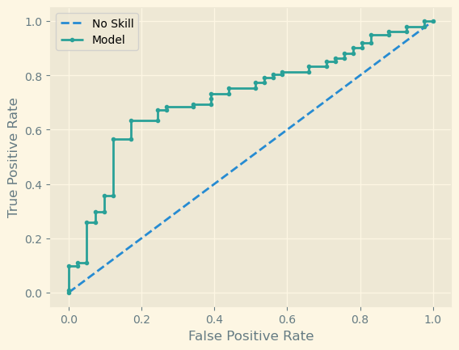

```
No Skill PR AUC: 0.817
Model PR AUC: 0.864
```

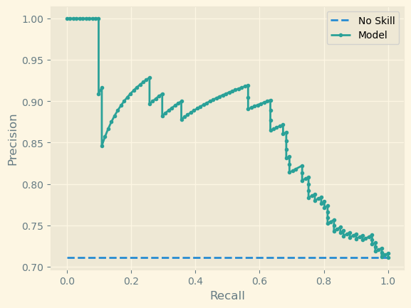

```
array([1, 1, 1, 1, 1, 1, 0, 0, 1, 1, 0, 1, 0, 0, 1, 1, 0, 0, 0, 0, 0, 1,
       1, 1, 0, 0, 1, 0, 1, 0, 0, 0, 1, 0, 0, 0, 0, 1, 0, 1, 1, 1, 1, 1,
       1, 1, 1, 1, 0, 1, 1, 0, 0, 1, 1, 0, 1, 0, 1, 0, 1, 1, 1, 1, 1, 0,
       1, 1, 1, 1, 1, 0, 1, 1, 0, 0, 0, 0, 1, 1, 1, 0, 0, 1, 1, 0, 1, 1,
       0, 1, 1, 0, 1, 0, 1, 0, 1, 1, 0, 0, 1, 1, 1, 1, 0, 0, 0, 1, 1, 1,
       1, 1, 1, 1, 1, 1, 0, 1, 1, 0, 1, 1, 0, 1, 0, 1, 1, 1, 1, 1, 0, 0,
       0, 0, 0, 1, 1, 1, 0, 1, 1, 1], dtype=int64)
```

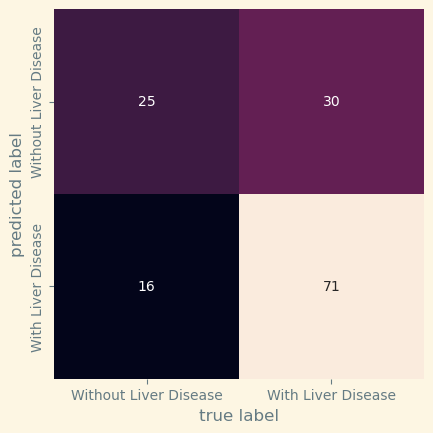

```python
parameters = {
    'penalty' : ['l1','l2'],
    'C'       : np.logspace(-3,3,7),
    'solver'  : ['newton-cg', 'lbfgs', 'liblinear'],
    'class_weight' : ['balanced', {0: 55, 1: 45}, {0: 60, 1: 40}, {0: 100, 1: 10}, {0: 70, 1: 30}]
}

model_evaluation(lr, parameters, cv, "f1_macro")
```

As we can notice, we have no particular improvement in performance by using PCA instead of ANOVA Feature Selection. This could make sense, since PCA is usually involvev when the number of features is very high, while this is not the case with such dataset.

### Results

In terms of Accuracy, the best performing models is, obviously, the Logistic Regression without class weights. As already mentioned, this is not a good result because the good accuracy here is due to datasat imbalance. If we take into account F1-score, in particular the average between F1-score for Positive label and F1-score for Negative label, we see that the best model is the Logistic Regression with class weights. For what concerns SVM, we saw how this model tend to be more correct on Negative samples but, at the same time, produces a higher number of False Negatives. False Negatives can cause many problem in a classification task of this kind. Finally, it seems that K-NN with over sampling and Logistic Regression with class weights are the two most reasonable models: they have good metric with respect to all the models and they are more balanced in the performance of both labels, with respect to SVM model.

It is then reasonable to choose one of these two last model to perform the task of predicting patients with liver disease. One can argue that the results are not fantastic but this can be attributed to the general class imbalance that the dataset present. Such issue can be eased by oversampling or class weight but still it remains a problem that makes any classification task more difficult.

Another point that can be explored with more advanced technique is the understanding of the distribution of some of the variables in this dataset. Many of the variables of this dataset were characterized by not-normal distributions. I tried to check if they were log-normal (given their highly skewed shape) but it was not the case. Maybe, the results we obtained is also determined by outliers that were not removed. However, without having insight about the distribution it is difficult to identy them in a proper general way, without losing relevant data.